# 2026-11-20_hw-03

Chris

2026-11-20

https://github.com/ChrisW12372/2026-11-20_p8108_hw-03.git

```r
library(tidyverse)
library(kableExtra)
library(survival)

actg320 <- read_csv("data/hw3_actg320.csv")
```

# 1 problem 1

## 1.1 part a

I expect to use a linear term for baseline CD4, scaled per 50 cells, so that a 50-cell increase has the same hazard ratio at any starting CD4 count. The alternative is a restricted cubic spline with knots at the 10th, 50th, and 90th percentiles of baseline CD4. I would favor the spline if a likelihood ratio test for nonlinearity gave $p < 0.05$, using the same participants and other covariates in both models. Follow-up starts at study entry and is measured in months. The event is the first AIDS-defining diagnosis or death, whichever occurs first. I assume that censoring is independent of the event time conditional on the model covariates. The treatment contrast compares assignment to combination therapy with indinavir to assignment to combination therapy without indinavir.

```r
counts <- actg320 |>
  group_by(k100, trt) |>
  summarise(
    Participants = n(),
    Events = sum(event == 1),
    .groups = "drop"
  ) |>
  arrange(desc(k100), trt) |>
  transmute(
    Karnofsky = if_else(k100 == 1, "100", "< 100"),
    Treatment = if_else(trt == 1, "With indinavir", "Without indinavir"),
    Participants,
    Events
  )
```

```r
counts |>
  kbl(
    caption = "Participants and events by treatment and baseline Karnofsky score",
    col.names = c("Karnofsky score", "Treatment", "Participants", "Events"),
    align = c("l", "l", "r", "r"),
    booktabs = TRUE
  ) |>
  kable_styling(full_width = FALSE)
```

Participants and events by treatment and baseline Karnofsky score

| Karnofsky score | Treatment | Participants | Events |
| --- | --- | --- | --- |
| 100 | Without indinavir | 202 | 11 |
| 100 | With indinavir | 194 | 6 |
| < 100 | Without indinavir | 375 | 52 |
| < 100 | With indinavir | 380 | 27 |

The treatment hazard ratio is expected to be least precise in the Karnofsky score 100 group. This group had 17 events (6 with indinavir and 11 without), compared with 79 events (27 with indinavir and 52 without) in the group with scores below 100. The smaller number of events in both arms gives less information for estimating the treatment hazard ratio.

## 1.2 part b

```r
# Use the same complete cases for all five models.
dat_b <- actg320 |>
  filter(complete.cases(months, event, trt, k100, cd4)) |>
  mutate(
    x = cd4 / 50,
    cd4_group = case_when(
      cd4 < 50 ~ "<50",
      cd4 <= 100 ~ "50–100",
      TRUE ~ ">100"
    ),
    cd4_group = factor(cd4_group, levels = c(">100", "<50", "50–100"))
  )
```

```r
m0 <- coxph(Surv(months, event) ~ trt,
            data = dat_b, ties = "efron")
m1 <- coxph(Surv(months, event) ~ trt + k100 + x,
            data = dat_b, ties = "efron")
m2 <- coxph(Surv(months, event) ~ trt + k100 + sqrt(x),
            data = dat_b, ties = "efron")
m3 <- coxph(Surv(months, event) ~ trt + k100 + cd4_group,
            data = dat_b, ties = "efron")
m4 <- coxph(Surv(months, event) ~ trt + k100 + x + I(x^2),
            data = dat_b, ties = "efron")
```

```r
models <- list(M0 = m0, M1 = m1, M2 = m2, M3 = m3, M4 = m4)

model_table <- tibble(
  Model = names(models),
  Coefficients = vapply(models, function(fit) length(coef(fit)), integer(1)),
  Neg2LogLik = vapply(models, function(fit) {
    -2 * as.numeric(logLik(fit))
  }, numeric(1)),
  AIC = vapply(models, AIC, numeric(1))
) |>
  mutate(DeltaAIC = AIC - min(AIC))

model_table |>
  kbl(
    caption = "Comparison of Cox models",
    col.names = c(
      "Model", "Coefficients", "-2 log partial likelihood",
      "AIC", "Delta AIC"
    ),
    digits = 2,
    booktabs = TRUE
  ) |>
  kable_styling(full_width = FALSE)
```

Comparison of Cox models

| Model | Coefficients | -2 log partial likelihood | AIC | Delta AIC |
| --- | --- | --- | --- | --- |
| M0 | 1 | 1306.19 | 1308.19 | 68.10 |
| M1 | 3 | 1234.09 | 1240.09 | 0.00 |
| M2 | 3 | 1239.65 | 1245.65 | 5.56 |
| M3 | 4 | 1243.11 | 1251.11 | 11.02 |
| M4 | 4 | 1234.09 | 1242.09 | 2.00 |

```r
# M4 adds one quadratic term to M1.
lr_stat <- 2 * as.numeric(logLik(m4) - logLik(m1))

lrt_table <- tibble(
  Comparison = "M1 vs. M4",
  `LR statistic` = lr_stat,
  df = 1,
  `p-value` = format.pval(
    pchisq(lr_stat, df = 1, lower.tail = FALSE),
    digits = 3,
    eps = 0.001
  )
)

lrt_table |>
  kbl(
    caption = "Likelihood ratio test for CD4 curvature",
    digits = 3,
    booktabs = TRUE
  ) |>
  kable_styling(full_width = FALSE)
```

Likelihood ratio test for CD4 curvature

| Comparison | LR statistic | df | p-value |
| --- | --- | --- | --- |
| M1 vs. M4 | 0.001 | 1 | 0.971 |

M1, which adjusts for treatment and baseline Karnofsky score and models CD4 linearly, had the lowest AIC (1240.09). M4 had the next lowest AIC ($\Delta\mathrm{AIC}=2.00$). Adding the quadratic CD4 term produced almost no improvement in fit (likelihood-ratio $\chi^2_1=0.001$, $p=0.971$). These results favor M1 among the models considered.

M1 and M2 are nonnested. M1 uses $x=\mathrm{CD4}/50$, while M2 uses $\sqrt{x}$, and no coefficient restriction reduces either model to the other. The nested-model likelihood-ratio test therefore does not apply. AIC favors M1 over M2 by 5.56 points.

## 1.3 part c

```r
# Hold treatment and Karnofsky score fixed at both CD4 values.
cd4_pair <- data.frame(
  x = c(25, 125) / 50,
  trt = c(0, 0),
  k100 = c(1, 1)
)

cd4_models <- list(M1 = m1, M4 = m4)

cd4_hr <- vapply(cd4_models, function(fit) {
  lp <- predict(fit, newdata = cd4_pair, type = "lp")
  exp(lp[1] - lp[2])
}, numeric(1))
```

```r
cd4_hr_table <- data.frame(
  Model = names(cd4_models),
  `CD4 form` = c("Linear", "Linear and quadratic"),
  `Hazard ratio` = unname(cd4_hr),
  check.names = FALSE
)

cd4_hr_table |>
  kableExtra::kbl(
    caption = "Hazard ratios comparing CD4 of 25 with CD4 of 125",
    align = c("l", "l", "r"),
    digits = 3,
    booktabs = TRUE
  ) |>
  kableExtra::kable_styling(full_width = FALSE)
```

Hazard ratios comparing CD4 of 25 with CD4 of 125

| Model | CD4 form | Hazard ratio |
| --- | --- | --- |
| M1 | Linear | 4.700 |
| M4 | Linear and quadratic | 4.702 |

At the same treatment assignment and baseline Karnofsky score, participants with a CD4 count of 25 had an estimated hazard of an AIDS-defining diagnosis or death about 4.7 times that of participants with a CD4 count of 125. The estimates were nearly identical under M1 (HR = 4.700) and M4 (HR = 4.702).

I would choose M1. It had the lowest AIC (1240.09), and adding a quadratic term in M4 barely improved the fit (likelihood-ratio test, $p = 0.971$). One limitation is that this contrast uses only two CD4 values. Agreement at these values leaves open the possibility that the models differ elsewhere in the CD4 range.

The closest challenge to my initial preference for a linear CD4 term was that M4’s AIC was only 2.00 points higher than M1’s. The nearly identical hazard ratios and the small gain in fit favor keeping M1. This comparison addresses quadratic curvature. The spline-based criterion specified in part (a) remains unevaluated.

## 1.4 part d

```r
m_int <- survival::coxph(
  survival::Surv(months, event) ~ trt * k100 + x,
  data = dat_b,
  ties = "efron"
)

# Test whether the treatment HR differs by Karnofsky group.
lr_stat <- 2 * as.numeric(logLik(m_int) - logLik(m1))
lr_p <- pchisq(lr_stat, df = 1, lower.tail = FALSE)

interaction_test <- data.frame(
  Comparison = "M1 vs. M1 with treatment interaction",
  `LR statistic` = lr_stat,
  df = 1,
  `p-value` = format.pval(lr_p, digits = 3, eps = 0.001),
  check.names = FALSE
)

interaction_test |>
  kableExtra::kbl(
    caption = "Likelihood ratio test for the treatment by Karnofsky interaction",
    digits = 3,
    booktabs = TRUE
  ) |>
  kableExtra::kable_styling(full_width = FALSE)
```

Likelihood ratio test for the treatment by Karnofsky interaction

| Comparison | LR statistic | df | p-value |
| --- | --- | --- | --- |
| M1 vs. M1 with treatment interaction | 0.219 | 1 | 0.64 |

```r
# k100 = 0: beta_trt
# k100 = 1: beta_trt + beta_interaction
terms <- c("trt", "trt:k100")
b <- coef(m_int)[terms]
V <- vcov(m_int)[terms, terms]

C <- rbind(
  c(1, 0),  # Karnofsky < 100
  c(1, 1)   # Karnofsky = 100
)

group_log_hr <- drop(C %*% b)
group_se <- sqrt(diag(C %*% V %*% t(C)))

log_hr <- c(coef(m0)["trt"], coef(m1)["trt"], group_log_hr)
se <- c(
  sqrt(vcov(m0)["trt", "trt"]),
  sqrt(vcov(m1)["trt", "trt"]),
  group_se
)
z <- qnorm(0.975)

treatment_hr_table <- data.frame(
  Model = c("M0", "M1", "Interaction model", "Interaction model"),
  Estimate = c(
    "Unadjusted",
    "Adjusted common HR",
    "Karnofsky < 100",
    "Karnofsky = 100"
  ),
  HR = exp(log_hr),
  `95% CI` = sprintf(
    "%.3f to %.3f",
    exp(log_hr - z * se),
    exp(log_hr + z * se)
  ),
  check.names = FALSE
)

treatment_hr_table |>
  kableExtra::kbl(
    caption = "Treatment hazard ratios for IDV versus no IDV",
    align = c("l", "l", "r", "c"),
    digits = 3,
    booktabs = TRUE
  ) |>
  kableExtra::kable_styling(full_width = FALSE)
```

Treatment hazard ratios for IDV versus no IDV

| Model | Estimate | HR | 95% CI |
| --- | --- | --- | --- |
| M0 | Unadjusted | 0.504 | 0.331 to 0.769 |
| M1 | Adjusted common HR | 0.508 | 0.333 to 0.774 |
| Interaction model | Karnofsky < 100 | 0.485 | 0.305 to 0.773 |
| Interaction model | Karnofsky = 100 | 0.632 | 0.234 to 1.710 |

The likelihood-ratio test gave little evidence that the treatment hazard ratio varied by baseline Karnofsky score ($\chi^2_1 = 0.219$, $p = 0.64$). The hazard ratio for IDV versus no IDV was 0.485 (95% CI: 0.305 to 0.773) among participants with scores below 100 and 0.632 (95% CI: 0.234 to 1.710) among those with a score of 100. The latter group had only 17 events, compared with 79 in the lower-score group, and its confidence interval was much wider. Given the limited evidence for interaction and the imprecision in the score-100 group, I would report the common adjusted hazard ratio from M1 as the primary estimate (HR = 0.508, 95% CI: 0.333 to 0.774).

The unadjusted hazard ratio was 0.504, and adjustment for baseline CD4 and Karnofsky score changed it only slightly, to 0.508. Hazard ratios are noncollapsible, so adjusted and unadjusted estimates can differ even in a randomized trial without confounding. The observed difference alone cannot establish confounding.

# 2 problem 2

## 2.1 part a

Case A

```r
times <- c(6, 9)

case_a <- dat_b |>
  filter(cd4_group == "<50", k100 == 0)

cox_rows <- data.frame(
  trt = c(0, 1),
  k100 = c(0, 0),
  cd4_group = factor(
    rep("<50", 2),
    levels = levels(dat_b$cd4_group)
  )
)

survival_a <- lapply(seq_len(nrow(cox_rows)), function(i) {
  profile <- cox_rows[i, , drop = FALSE]
  cell <- case_a |> filter(trt == profile$trt)

  cox_curve <- survfit(m3, newdata = profile, stype = 2, ctype = 1)
  km_curve <- survfit(Surv(months, event) ~ 1, data = cell)

  n_risk <- vapply(times, function(t) sum(cell$months >= t), integer(1))
  km_surv <- summary(km_curve, times = times, extend = TRUE)$surv
  km_surv[n_risk == 0] <- NA_real_

  tibble(
    trt = profile$trt,
    Treatment = c("No IDV (assigned)", "IDV (paired)")[i],
    Month = times,
    Cox = summary(cox_curve, times = times)$surv,
    KM = km_surv,
    AtRisk = n_risk
  )
}) |>
  bind_rows()

survival_a |>
  transmute(
    Treatment,
    Month,
    `Cox survival (%)` = 100 * Cox,
    `KM survival (%)` = 100 * KM,
    `Number at risk` = AtRisk
  ) |>
  kbl(caption = "Six- and nine-month survival for Case A",
      digits = 2, booktabs = TRUE) |>
  kable_styling(full_width = FALSE)
```

Six- and nine-month survival for Case A

| Treatment | Month | Cox survival (%) | KM survival (%) | Number at risk |
| --- | --- | --- | --- | --- |
| No IDV (assigned) | 6 | 80.64 | 79.46 | 108 |
| No IDV (assigned) | 9 | 75.54 | 73.90 | 57 |
| IDV (paired) | 6 | 89.56 | 89.22 | 126 |
| IDV (paired) | 9 | 86.61 | 86.56 | 74 |

```r
ref_row <- data.frame(
  trt = 0,
  k100 = 0,
  cd4_group = factor(">100", levels = levels(dat_b$cd4_group))
)

assigned_row <- cox_rows[1, , drop = FALSE]

ref_curve <- survfit(m3, newdata = ref_row, stype = 2, ctype = 1)
s_ref_6 <- summary(ref_curve, times = 6)$surv

lp <- predict(m3, newdata = bind_rows(ref_row, assigned_row), type = "lp")
hr_vs_ref <- exp(lp[2] - lp[1])

tibble(
  `Reference survival at 6 months` = s_ref_6,
  `Assigned vs. reference HR` = hr_vs_ref,
  `Reconstructed survival` = s_ref_6^hr_vs_ref,
  `Direct Cox prediction` = survival_a$Cox[
    survival_a$trt == 0 & survival_a$Month == 6
  ]
) |>
  kbl(caption = "Reconstruction of the assigned row's six-month prediction",
      digits = 4, booktabs = TRUE) |>
  kable_styling(full_width = FALSE)
```

Reconstruction of the assigned row’s six-month prediction

| Reference survival at 6 months | Assigned vs. reference HR | Reconstructed survival | Direct Cox prediction |
| --- | --- | --- | --- |
| 0.9728 | 7.7905 | 0.8064 | 0.8064 |

```r
at_9 <- survival_a |> filter(Month == 9)

difference_9 <- tibble(
  Method = c("Cox", "Kaplan--Meier"),
  `IDV minus no IDV (percentage points)` = 100 * c(
    at_9$Cox[at_9$trt == 1] - at_9$Cox[at_9$trt == 0],
    at_9$KM[at_9$trt == 1] - at_9$KM[at_9$trt == 0]
  )
)

difference_9 |>
  kbl(caption = "Treatment differences in nine-month survival",
      digits = 2, booktabs = TRUE) |>
  kable_styling(full_width = FALSE)
```

Treatment differences in nine-month survival

| Method | IDV minus no IDV (percentage points) |
| --- | --- |
| Cox | 11.07 |
| Kaplan–Meier | 12.66 |

```r
follow_up_a <- case_a |>
  group_by(trt) |>
  summarise(
    `Events after month 6 through month 9` =
      sum(event == 1 & months > 6 & months <= 9),
    `Last observed follow-up (months)` = max(months),
    `Number at risk at month 12` = sum(months >= 12),
    .groups = "drop"
  ) |>
  mutate(Treatment = if_else(trt == 0, "No IDV", "IDV"), .before = 1) |>
  select(-trt)

follow_up_a |>
  kbl(caption = "Event counts and follow-up for Case A",
      digits = 3, booktabs = TRUE) |>
  kable_styling(full_width = FALSE)
```

Event counts and follow-up for Case A

| Treatment | Events after month 6 through month 9 | Last observed follow-up (months) | Number at risk at month 12 |
| --- | --- | --- | --- |
| No IDV | 7 | 11.447 | 0 |
| IDV | 3 | 11.678 | 0 |

For Case A (CD4 $<50$ and Karnofsky score $<100$), the assigned arm was no IDV. At six months, the M3 reference profile (no IDV, Karnofsky score $<100$, and CD4 $>100$) had an estimated event-free survival of 0.9728. The assigned profile had a hazard 7.7905 times that of the reference profile. Using the unrounded estimates, the Cox survival prediction is
$$\widehat S_{\mathrm{assigned}}(6)
= \widehat
S_{\mathrm{ref}}(6)^{\widehat{\mathrm{HR}}_{\mathrm{assigned/ref}}}
= 0.8064,$$
which matches the direct prediction.

At nine months, estimated event-free survival was higher with IDV by 11.07 percentage points under Cox and 12.66 percentage points under Kaplan–Meier. I would report the Kaplan–Meier estimates to the editor (86.56% with IDV and 73.90% without IDV) because they come directly from the two groups and both still had participants at risk at nine months (74 with IDV and 57 without IDV). Only 3 events occurred in the IDV arm and 7 in the no-IDV arm after month 6 through month 9, so the nine-month difference should be interpreted with some caution.

I would mark the 12-month estimates as unavailable. The last observed follow-up was 11.447 months without IDV and 11.678 months with IDV, and neither arm had anyone at risk at month 12. Carrying each curve forward would assign zero additional event hazard from that arm’s last observed follow-up to month 12. I would report the nine-month estimates and state that follow-up in this subgroup was insufficient to estimate one-year event-free survival.

## 2.2 part b

```r
ph_m1 <- cox.zph(m1, transform = "km")

ph_table <- as.data.frame(ph_m1$table[c("trt", "x"), , drop = FALSE])
rownames(ph_table) <- c("Treatment", "Baseline CD4 per 50 cells")

ph_table |>
  kbl(
    caption = "Term-specific proportional hazards tests for M1",
    col.names = c("Chi-square", "df", "p-value"),
    row.names = TRUE,
    digits = 3,
    booktabs = TRUE
  ) |>
  kable_styling(full_width = FALSE)
```

Term-specific proportional hazards tests for M1

|  | Chi-square | df | p-value |
| --- | --- | --- | --- |
| Treatment | 1.962 | 1 | 0.161 |
| Baseline CD4 per 50 cells | 3.998 | 1 | 0.046 |

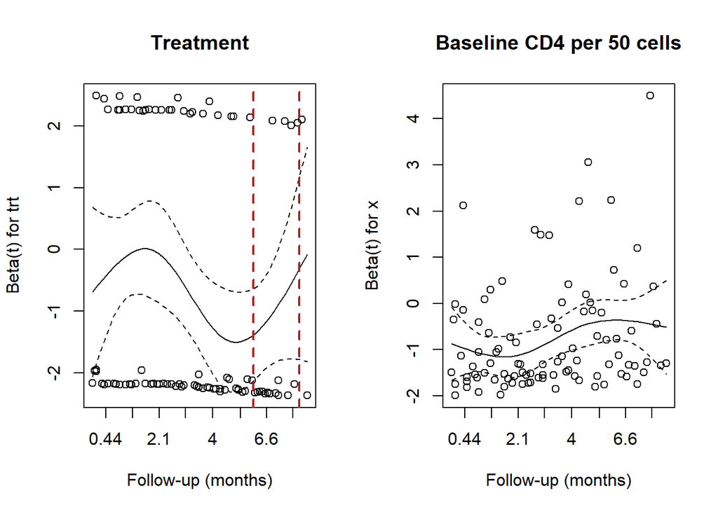

```r
# Start with this example, then choose the window from the plots.
window_term <- "trt"          # Use "x" to mark the CD4 plot instead.
window_months <- c(6, 9)

# Convert month boundaries to the plot's KM-transformed coordinates.
window_km <- approx(
  x = ph_m1$time,
  y = ph_m1$x,
  xout = window_months
)$y
old_par <- par(mfrow = c(1, 2))

for (term in c("trt", "x")) {
  label <- if (term == "trt") "Treatment" else "Baseline CD4 per 50 cells"

  plot(ph_m1, var = term, main = label, xlab = "Follow-up (months)")

  if (term == window_term) {
    abline(v = window_km, col = "firebrick", lty = 2, lwd = 2)
  }
}
```

```r
par(old_par)
```

```r
window_start <- window_months[1]
window_end <- window_months[2]

dat_b |>
  group_by(trt) |>
  summarise(
    `At risk at start` = sum(months >= window_start),
    `Events in window` = sum(
      event == 1 & months > window_start & months <= window_end
    ),
    `At risk at end` = sum(months >= window_end),
    .groups = "drop"
  ) |>
  mutate(Treatment = if_else(trt == 1, "IDV", "No IDV"), .before = 1) |>
  select(-trt) |>
  kbl(
    caption = sprintf(
      "Risk sets and events in the marked window (%g to %g months)",
      window_start, window_end
    ),
    booktabs = TRUE
  ) |>
  kable_styling(full_width = FALSE)
```

Risk sets and events in the marked window (6 to 9 months)

| Treatment | At risk at start | Events in window | At risk at end |
| --- | --- | --- | --- |
| No IDV | 403 | 12 | 211 |
| IDV | 432 | 4 | 242 |

```r
m1_tv <- coxph(
  Surv(months, event) ~ trt + k100 + x + tt(trt),
  data = dat_b,
  ties = "efron",
  tt = function(x, t, ...) x * log(t / 6)
)

report_months <- c(3, 6, 9)
b <- coef(m1_tv)

log_hr <- b["trt"] + b["tt(trt)"] * log(report_months / 6)

# At month 6, the time-varying term is zero.
se_6 <- sqrt(vcov(m1_tv)["trt", "trt"])
ci_6 <- exp(b["trt"] + c(-1, 1) * qnorm(0.975) * se_6)

hr_table <- tibble(
  Month = report_months,
  HR = exp(log_hr),
  `95% CI` = c("", sprintf("%.3f to %.3f", ci_6[1], ci_6[2]), "")
)

hr_table |>
  kbl(
    caption = "Time-varying hazard ratios for IDV versus no IDV",
    align = c("c", "r", "c"),
    digits = 3,
    booktabs = TRUE
  ) |>
  kable_styling(full_width = FALSE)
```

Time-varying hazard ratios for IDV versus no IDV

| Month | HR | 95% CI |
| --- | --- | --- |
| 3 | 0.483 |  |
| 6 | 0.431 | 0.245 to 0.758 |
| 9 | 0.403 |  |

I would report a constant treatment HR as a summary of the observed follow-up. The Schoenfeld test gave limited evidence of a time-varying treatment effect ($\chi^2_1 = 1.962$, $p = 0.161$). In the model with a treatment-by-log-time interaction, the estimated HRs for IDV versus no IDV were 0.483, 0.431, and 0.403 at 3, 6, and 9 months, respectively. The 6-month HR was 0.431 (95% CI: 0.245 to 0.758).

The strongest evidence against a constant treatment HR was the upturn in the smoothed treatment coefficient between months 6 and 9, which suggests that the benefit of IDV may have weakened in that window. The log-time model showed a modest decline in the HR, so the two analyses suggest different directions of change over this interval. The risk set shrank from 835 to 453 participants, and only 16 events occurred in that window (12 without IDV and 4 with IDV), making the late trend hard to estimate precisely.

For baseline CD4, the Schoenfeld test gave some evidence against proportional hazards ($\chi^2_1 = 3.998$, $p = 0.046$). The smoothed coefficient was more negative early in follow-up and became less negative later, suggesting that the association between higher baseline CD4 and lower hazard weakened over time.

## 2.3 part c

```r
dfbetas_m1 <- residuals(m1, type = "dfbetas")
trt_col <- match("trt", names(coef(m1)))

diagnostics <- tibble(
  id = dat_b$id,
  deviance = as.numeric(residuals(m1, type = "deviance")),
  dfbetas_trt = as.numeric(dfbetas_m1[, trt_col])
)

# Sort by absolute value, then by ID to break exact ties.
deviance_patient <- diagnostics |>
  arrange(desc(abs(deviance)), id) |>
  slice(1)

dfbetas_patient <- diagnostics |>
  arrange(desc(abs(dfbetas_trt)), id) |>
  slice(1)

tibble(
  Diagnostic = c("Deviance residual", "Treatment DFBETAS"),
  `Patient ID` = c(deviance_patient$id, dfbetas_patient$id),
  Value = c(deviance_patient$deviance, dfbetas_patient$dfbetas_trt),
  `Absolute value` = abs(Value)
) |>
  kbl(caption = "Patients selected by the two diagnostics",
      digits = 4, booktabs = TRUE) |>
  kable_styling(full_width = FALSE)
```

Patients selected by the two diagnostics

| Diagnostic | Patient ID | Value | Absolute value |
| --- | --- | --- | --- |
| Deviance residual | 374 | 3.5469 | 3.5469 |
| Treatment DFBETAS | 823 | 0.1528 | 0.1528 |

```r
dat_drop <- dat_b |> filter(id != dfbetas_patient$id)
m1_drop <- update(m1, data = dat_drop)

log_hr_full <- unname(coef(m1)["trt"])
log_hr_drop <- unname(coef(m1_drop)["trt"])

tibble(
  `Full M1 HR` = exp(log_hr_full),
  `Refitted M1 HR` = exp(log_hr_drop),
  `Change in log HR (refitted minus full)` = log_hr_drop - log_hr_full
) |>
  kbl(caption = "Treatment HR before and after omitting the DFBETAS-selected patient",
      digits = 4, booktabs = TRUE) |>
  kable_styling(full_width = FALSE)
```

Treatment HR before and after omitting the DFBETAS-selected patient

| Full M1 HR | Refitted M1 HR | Change in log HR (refitted minus full) |
| --- | --- | --- |
| 0.5079 | 0.4912 | -0.0334 |

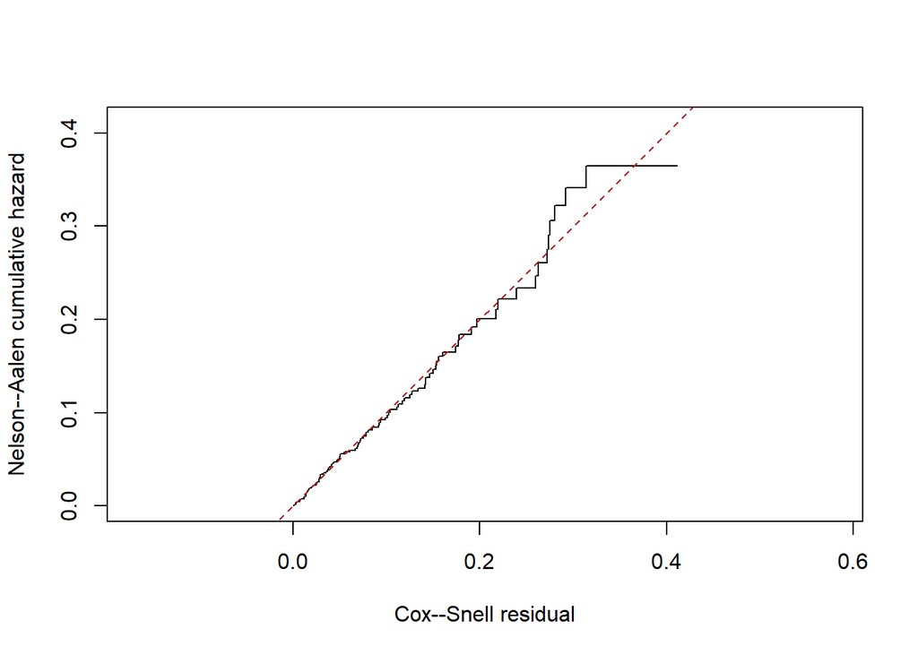

```r
# Evaluate each patient's fitted cumulative hazard at their observed time.
baseline <- basehaz(m1, centered = FALSE)
baseline_index <- findInterval(dat_b$months, baseline$time)
h0 <- c(0, baseline$hazard)[baseline_index + 1L]

lp <- predict(m1, newdata = dat_b, type = "lp", reference = "zero")
cox_snell <- h0 * exp(lp)

# Keep the original event indicator when fitting on the residual scale.
residual_fit <- survfit(
  Surv(cox_snell, dat_b$event) ~ 1,
  stype = 2,
  ctype = 1
)

plot_limit <- max(residual_fit$time, residual_fit$cumhaz)

plot(
  c(0, residual_fit$time),
  c(0, residual_fit$cumhaz),
  type = "s",
  xlim = c(0, plot_limit),
  ylim = c(0, plot_limit),
  asp = 1,
  xlab = "Cox--Snell residual",
  ylab = "Nelson--Aalen cumulative hazard"
)
abline(a = 0, b = 1, col = "firebrick", lty = 2)
```

```r
report_at <- 0.10
hazard_index <- findInterval(report_at, residual_fit$time)

tibble(
  `Residual value` = report_at,
  `Number at risk` = sum(cox_snell >= report_at),
  `Nelson--Aalen cumulative hazard` =
    c(0, residual_fit$cumhaz)[hazard_index + 1L]
) |>
  kbl(caption = "Cox--Snell residual check at 0.10",
      digits = 4, booktabs = TRUE) |>
  kable_styling(full_width = FALSE)
```

Cox–Snell residual check at 0.10

| Residual value | Number at risk | Nelson–Aalen cumulative hazard |
| --- | --- | --- |
| 0.1 | 359 | 0.0948 |

Patient 374 had the largest absolute deviance residual (3.5469), indicating the largest discrepancy between the observed follow-up and the fitted model. Patient 823 had the largest absolute DFBETAS for treatment (0.1528), indicating the greatest estimated influence on the treatment coefficient in standard-error units.

After omitting patient 823, the adjusted HR for IDV versus no IDV changed from 0.5079 to 0.4912, a change of $-0.0334$ on the log-HR scale. In both fits, the estimated hazard with IDV was about half that without IDV. I would retain both patients in the main analysis. Exclusion would require documented evidence of an uncorrectable data error or a violation of a prespecified eligibility criterion.

The Cox–Snell plot checks overall fit by comparing the observed cumulative hazard on the residual scale with the 45-degree line. The curve tracked the line closely up to about 0.25. At a residual of 0.10, 359 participants were at risk and the Nelson–Aalen estimate was 0.0948, close to the expected 0.10. The curve rose above the line and then flattened in the upper tail, where fewer participants were at risk and individual events produced larger steps. The plot therefore gives the clearest evidence about overall fit at smaller residual values, while the deletion analysis addresses the sensitivity of the treatment HR to one influential patient.

## 2.4 part d

Estimated probability of being alive and free of an AIDS-defining diagnosis in Case A

| Treatment | Month 6 | Month 9 | Month 12 |
| --- | --- | --- | --- |
| No IDV | 79.46% | 73.90% | Unavailable |
| IDV | 89.22% | 86.56% | Unavailable |

Among ACTG 320 participants with baseline CD4 counts below 50 and Karnofsky scores below 100, the estimated probability of being alive and free of an AIDS-defining diagnosis at six months was 89.22% with IDV and 79.46% without IDV. At nine months, the corresponding estimates were 86.56% and 73.90%, a difference of 12.66 percentage points in favor of IDV. I would report these Kaplan–Meier estimates through nine months and mark the one-year estimates as unavailable because follow-up in both groups ended before 12 months. In the full trial analysis, removing the patient who most influenced the treatment estimate changed the hazard ratio only slightly, from 0.508 to 0.491. I would therefore retain the full-trial hazard ratio as a summary and report the subgroup’s event-free probabilities alongside it.

AI Usage: I used ChatGPT 6.2 medium created by OpenAI. It helped me with creating tables using `kableExtra`, and organising latex codes.

Question: About repeating the 12.66-percentage-point difference. How precise is that estimate, given how many people were still being followed at nine months?

I would change the sentence into: At nine months, an estimated 87% of participants assigned to IDV and 74% of those assigned to no IDV were alive and free of an AIDS-defining diagnosis, a difference of about 13 percentage points.